# checkpoint 4

Carlos Interaminense

August 7, 2017

```r
library(plotly)
library(ggplot2)
library(GGally)
library(dplyr)
library(tidyverse)
library(resample) # <-- Para bootstrap!
library(boot)
theme_set(theme_bw())
```

# Testes de hipótese x Intervalos de Confiança

Neste relatório vamos refazer uma análise que foi realizada no checkpoint anterior. Mas agora, vamos considerar testes de hipótese em lugar de intervalos de confiança. No final deste relatório vamos realizar uma comparação entre as duas respostas (testes de hipótese de Intervalos de confiança). Também *tentaremos* fazer uma breve explicação sobre p-valor…

*Pergunta escolhida para responder usando Testes de Hipótese:*

## No geral (independente da linguagem de programação), as pessoas programam mais durante a semana ou no final de semana? Essa diferença é grande?

O primeiro passo é carregar os dados. *No checkpoint anterior nós já descrevemos os dados, por isso não serão descritos neste relatório*

```r
#Carregando os dados
dados = read_csv("./github-users-commiting-filetypes.csv");
```

Para responder esta pergunta, temos que saber se os usuários modificaram os arquivos durante a semana ou no final de semana e, como queremos saber o resultado independente da linguagem de programação, temos que agrupar os dados pela a data, somando as modificações daquele dia para qualquer linguagem de programação.

```r
dados$date <- paste(dados$month_day, dados$the_month, dados$the_year, sep = "-")

dados.agrupados <- aggregate(dados[, 5], list(dados$date), sum)

dados.agrupados  <- dados.agrupados %>%
  mutate(nome_dia = weekdays(as.Date(Group.1,'%d-%m-%Y')) )

dados.agrupados  <- dados.agrupados %>%
    mutate(is_fds = (nome_dia == 'sábado' | nome_dia== 'domingo' )   )
```

### Usando Intervalos de Confiança

```r
# Galera do FDS
b1 = dados.agrupados %>%
  filter(is_fds) %>%
  bootstrap(median(users))

median.fds = b1 %>%
  CI.percentile(props = c(.025, .975))

# Galera da semana (seg-sexta)
b2 = dados.agrupados %>%
  filter(is_fds != TRUE) %>%
  bootstrap(median(users))

median.semana = b2 %>%
  CI.percentile(props = c(.025, .975))

df.medians = data.frame(rbind(median.fds, median.semana))
```

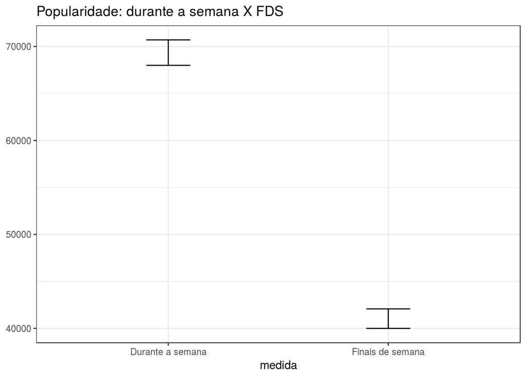

```r
df.medians$medida= c("Finais de semana", "Durante a semana")

df.medians %>%
  ggplot(aes(x = medida, ymin = X2.5., ymax = X97.5.)) +
  geom_errorbar(width = .2) +
  ggtitle("Popularidade: durante a semana X FDS")
```

A partir do gráfico acima (usando intervalos de confiança) percebemos que as pessoas preferem programar durante a semana do que no final de semana e podemos perceber também que a diferença é grande.

### Usando Testes de Hipótese

O primeiro passo é guardar a diferença das medianas dos *commits* das pessoas que programaram durante a semana com os que programaram nos finais de semana.

```r
medianas_semanaXfds = dados.agrupados %>%
  group_by(is_fds) %>%
  summarise(mediana = median(users))

medianas_semanaXfds
```

```
## # A tibble: 2 x 2
##   is_fds mediana
##    <lgl>   <dbl>
## 1  FALSE   69533
## 2   TRUE   40901
```

```r
diff.medianas_semanaXfds = diff(medianas_semanaXfds$mediana)
diff.medianas_semanaXfds
```

```
## [1] -28632
```

A diferença foi de -28632.

Agora vejamos o quão diferente seria encontrarmos uma diferença do tamanho que encontramos (-28632) *se não houvesse associação entre o período da semana (dia de semana ou final de semana) e a quantidade de commit*. A situação onde não existe associação é chamada de *hipótese nula*. Se a diferença que observamos em nossa amostra acontece facilmente na hipótese nula, isso significa que não temos evidência forte de associação: o que observamos acontece também quando não há associação.

No caso onde a diferença que observamos é improvável na hipótese nula, então observamos algo que é indicativo de associação. Repare que é uma dupla negação: se **não acontece** associação como a que vimos na amostra na situação onde **não** há associação, então temos evidência de que há associação.

Agora, vamos verificar na prática o que discutimos acima…

```r
set.seed(1)
diffs = replicate(10000, {
  medianas = dados.agrupados %>%
    mutate(id_embaralhado = sample(is_fds, n())) %>%
    group_by(id_embaralhado) %>%
    summarise(mediana = median(users))
  return(diff(medianas$mediana))
})
glimpse(diffs)
```

```
##  num [1:10000] 1249 -1195 -877 -3594 -1213 ...
```

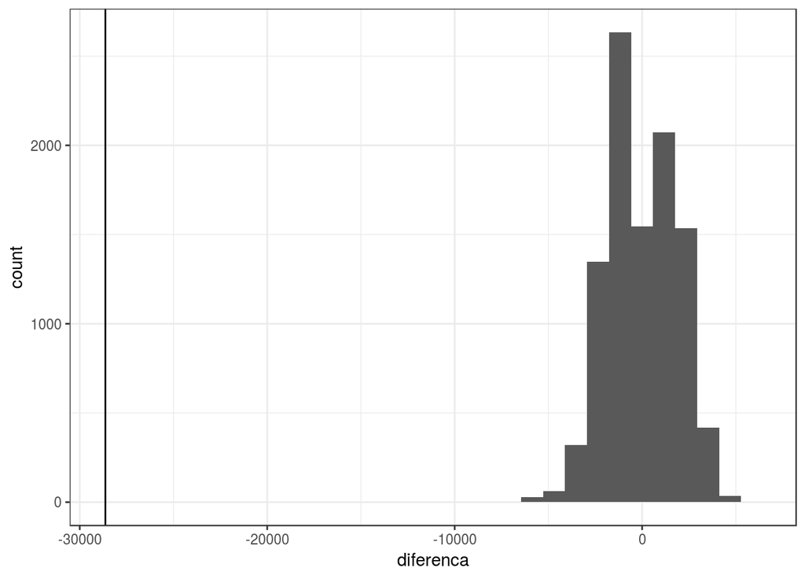

```r
tibble(diferenca = diffs) %>%
  ggplot(aes(x = diferenca)) +
  geom_histogram(bins = 30) +
  geom_vline(xintercept = diff.medianas_semanaXfds)
```

```r
p.valor = sum(abs(diffs) >= abs(diff.medianas_semanaXfds)) / length(diffs)
p.valor
```

```
## [1] 0
```

Sabendo que a nossa hipótese nula é que não há relação entre o período da semana e os commits, percebemos a partir do gráfico acima que em nenhum caso ela foi verdadeira, ou seja, em nenhum caso o valor da diferença, em módulo, foi maior que -28632, também em módulo (computado anteriormente neste relatório), ou seja, o p-valor foi igual a 0 (ZERO). O que significa que a nossa hipótese nula é falsa e, portanto, concluimos que existe uma associação entre o período da semana e os commits e que os usuários do GitHub preferem programar durante a semana do que os finais de semana, independente da linguagem de programação.

**Dessa forma, respondemos a nossa pergunta inicial usando intervalos de confiança e testes de hipótese, e chegamos a mesma conclusão: Os usuários do GitHub, no geral, preferem programar durante a semana do que os finais de semana, independente da linguagem de programação. A diferença entre as duas respostas (Intervalos de confiança e Testes de hipótese) está no fato de que, usar Intervalos de confiança, controlamos a significância estatística do resultado e sabemos a faixa de valores que esperamos que aconteça com uma confiança de X%, em que, quanto maior a confiança maior será a faixa de valores, o que nao temos nos testes de hipóteses.

**Aproveitando o nosso exemplo para explicar o que é o p-valor…** **p-valor** é a probabilidade de acontecer um exemplo em que a hipótese nula seja verdadeira, no nosso exemplo é a probabilidade de acontecer um exemplo de uma amostra que a diferença entre a mediana dos commits nos finais de semana e a mediana dos commits nos dias da semana seja maior ou igual (**em módulo**) ao que obtivemos na amostra (-28632), também em módulo. Um p-valor <= 0.05 (5%) é considerado bom, na literatura.